# Лабораторная работа № 5

Анализ файловой системы Linux. Команды для работы с файлами и каталогами

Шулуужук Айраана Вячеславовна НПИбд-02-22

Российский университет дружбы народов, Москва, Россия

06 матра 2023

## Докладчик

- Шулуужук Айраана Вячеславовна
- НПИбд-02-22
- 1132221890
- Российский университет дружбы народов

# Цели и задачи

Ознакомление с файловой системой Linux, её структурой, именами и содержанием каталогов. Приобретение практических навыков по применению команд для работы с файлами и каталогами, по управлению процессами (и работами), по проверке использования диска и обслуживанию файловой системы.

# Выполнение лабораторной работы

## Команда cp

Копируем файл /usr/include/sys/io.h в домашний каталог и назовем его equipment, используя команду cp

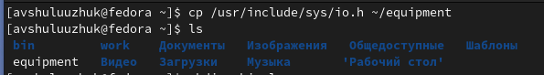

файл equipment

## Команда mv

Создаем каталог ski.plases и переместим в созданную директорию файл equipment (команда mv)

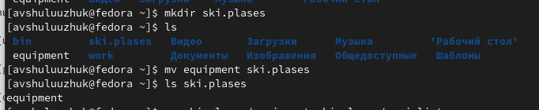

перемещение файла equipment в каталог ski.plases

## Команда touch

Создаем файл abc1 (команда touch) и копируем его в каталог ski.plases, назовем equiplist2

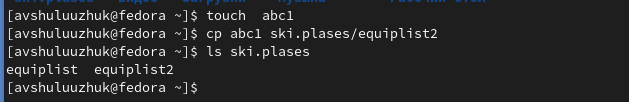

каталог ski.plases

## Команда chmod

Создадим файлы my_os, feathers и каталоги australia, play. Присвоим им следующие права, используя команду chmod

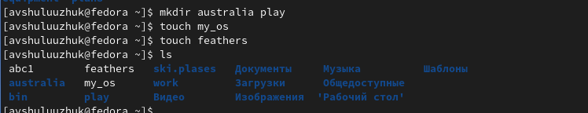

создание необходимых файлов и каталогов

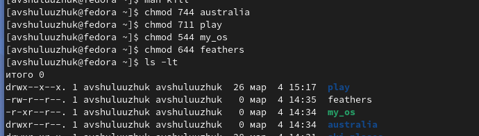

изменение прав для файлов и каталогов

## Команда cat

Просмотрим содержимое файла /etc/passwd

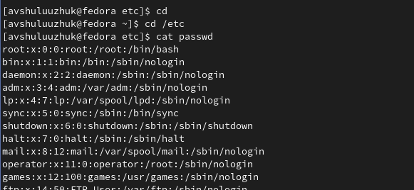

файл passwd

## Команда mv

Переместим файл file.old в каталог play

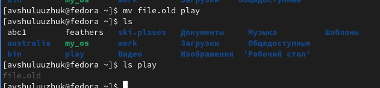

перемещение файла file.old в каталог play

## Команда chmod

Лишим владельца файла feathers права на чтение, попробуем просмотреть и скопировать этот файл. В результате без прав на чтение владелец файла не сможет просмотреть и скопировать его

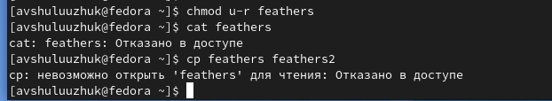

изменение прав доступа на чтение к файлу feathers

## Команда chmod

Лишим владельцу каталога play права на выполнение и попробуем перейти в него. Без прав на выполнение владелец не сможет перейти в него. Далее восстановим владельцу права на выполнение

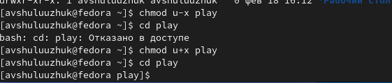

изменение прав доступа на выполнение к каталогу play

## Команда man mount

Команда mount используется для просмотра используемых в операционной системе файловых систем

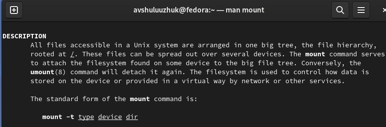

man mount

## Команда man fsck

Команда fsck нужна для проверки и восстановления целостности файловой системы

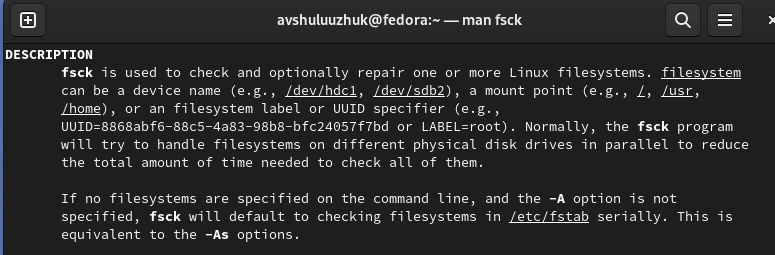

man fsck

## Команда man mkfs

Команда mkfs используется для создания файловой системы Linux на устройстве, обычно в разделе жесткого диска.

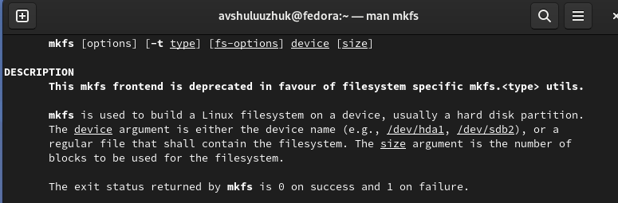

man mkfs

# Выводы

В ходе выполения лабораторной работы мы ознакомились с файловой системой Linux, ее структурой, именами и содержанием каталогов. Приобрели практические навыки по применению команд для работы с файлами и каталогами, по управлению процессами и работами, по проверке использования диска и обслуживанию файловой системы